# Diabetes prediction model

Mohammad Shahin, Baraa EL Ghalayini, Anas Al Baqeri

(December 10, 2023)

# Introduction

Diabetes is a widespread and pressing health issue globally, affecting millions of people today. The goal of the project is to develop a machine learning model capable of predicting the likelihood of an individual developing diabetes based on relevant observed features including but limited to: gender, age, smoking and other relevant factors in our dataset. This project is relevant to the team’s interests as each one of us is working with similar machine learning medical-applications such as iris diseases recognition and classification and choosing a project as such creates a cohesive learning experience for the team. Moreover, other factors that were considered while choosing this problem was the availability of well-documented datasets that readily available and the significance of issue in the health domain as 422 million people today suffer from diabetes, that is 0.52% of the word’s population.

## Dataset Selection and Description

### Target Variable:

- Binary Variable (0 or 1) indicating the presence (1) or absence of diabetes.

### Rationale for Dataset Selection:

All in all, the selected dataset provides a rich but also challenging environment for developing a diabetes prediction model that encompasses a mass of features crucial for accurate and reliable predictions in the context of diabetes assessment.

# Setup

## Overview

Our project is structured to use R and Python in tandem, capitalizing on the strengths of each language. R, with its rich ecosystem of statistical packages and ease of data manipulation, serves as our primary environment for data analysis, while Python, known for its computational efficiency and powerful machine learning libraries, is employed for specific tasks requiring extensive computational resources.

## R Environment and RStudio

### RStudio as the Primary IDE:

- RStudio is our primary Integrated Development Environment (IDE), chosen for its user-friendly interface and robust features that support R programming.
- It provides an efficient workspace for writing scripts, viewing data, and managing packages.

### R Packages and Libraries:

- We leverage R’s extensive package ecosystem for data processing and preliminary analysis.
- Key packages include:
  - `tidyverse` for data manipulation and visualization (including packages like `ggplot2`, `dplyr`, `tidyr`).
  - `caret` for machine learning workflows.
  - `randomForest` and `xgboost` for ensemble methods in machine learning.
  - `e1071` for basic statistical operations.
  - Other relevant libraries for tasks such as parallel processing (`doParallel`, `iterators`) and additional data analysis techniques (`FactoMineR`, `lattice`).

### Data Handling and Analysis in R:

- Initial data loading, preprocessing (including feature engineering and data cleaning), and exploratory data analysis are conducted in R.
- We utilize R’s powerful data handling capabilities to manage and transform large datasets efficiently.

### Basic Model Development in R:

- Preliminary models (excluding SVM) are developed within RStudio, making use of R’s modeling packages.

# Running the Model

## Data Exploration

First Load required libraries.

```r
packages <- c("tidyverse", "e1071", "cowplot", "caret", "randomForest", "xgboost",
              "lattice", "readr", "doParallel", "iterators", "parallel", "dplyr",
              "rpart", "FactoMineR")

if(length(setdiff(packages, rownames(installed.packages()))) > 0) {
  install.packages(setdiff(packages, rownames(installed.packages())))
}

lapply(packages, library, character.only = TRUE)
```

Now we load our data set and assign diabetes_label to our target variable Remember to adjust path as needed.

```r
setwd("C:/College/10 -fall 2023/Data Mining/Final Projcet")
df <- read_csv("diabetes_prediction_dataset.csv")
diabetes_label <- df$diabetes
```

Checking for any missing values and Separating features from target variable

```r
colSums(is.na(df))
df_features <- df %>% select(-diabetes)
diabetes_label <- df$diabetes
```

Identify numeric and non-numeric columns

```r
numeric_col <- names(df_features)[sapply(df_features, is.numeric)]
non_numeric_col <- names(df_features)[!names(df_features) %in% numeric_col]
```

## Data Processing

Now that we made sure no missing values exist, we transform the smoking_history column in the df_features data frame by converting it to character type, reclassifying “not_current” as “former” and “ever” as “never,” and then converting it back to a factor. These steps are aimed to standardize and categorize smoking history information for subsequent analysis or modeling.

```r
df_features$smoking_history <- as.character(df_features$smoking_history)
df_features$smoking_history[df_features$smoking_history == "not_current"] <- "former"
df_features$smoking_history[df_features$smoking_history == "ever"] <- "never"
df_features$smoking_history <- as.factor(df_features$smoking_history)
```

We also created a new feature: forced_glucose_intake,the rationale for creating the new feature `forced_glucose_intake` is rooted in the observed relationship between age, hypertension, and blood glucose levels. Research suggests that older individuals with hypertension often reduce salt intake, leading to an increased intake of glucose to compensate. Additionally, hypertension medications are often coated with glucose. Considering that age-related declines in pancreatic volume make individuals over 40 more susceptible to diabetes, the new feature aims to capture a potential association between age, hypertension, and elevated glucose levels, providing a composite indicator that might be relevant for predicting diabetes risk in the dataset as these three factors cause a pressure point on the patient health as dealing with all the mentioned symptoms is similar to a Deadlock.

```r
df_features$forced_glucose_intake <- ifelse((df_features$blood_glucose_level > 140) & (df_features$hypertension == 1) & (df_features$age >= 40), 1, 0)
```

Now we encode non-numeric columns using Label Encoding We also select only numeric columns for clustering

```r
df_features[non_numeric_col] <- lapply(df_features[non_numeric_col], function(x) as.numeric(as.factor(x)))

df_numeric <- df_features %>% select_if(is.numeric)

df_scaled <- as.data.frame(scale(df_numeric ))
```

We now scale the data (excluding the label) and split our dataset to training and testing sets Seed is included to ensure reproducibility.

```r
df_scaled <- as.data.frame(scale(df_numeric ))

# Splitting the dataset into training and testing sets
set.seed(123)  # For reproducibility
partition <- createDataPartition(df$diabetes, p = 0.7, list = FALSE)
```

Now we prepare our dataset for the modeling process. We start by splitting the data, it is crucial that we already have scaled dataset before splitting.

```r
training_set <- df_scaled[partition, ]
testing_set <- df_scaled[-partition, ]

pre_proc_val <- preProcess(training_set, method = c("center", "scale"))
training_set_scaled <- predict(pre_proc_val, training_set)
testing_set_scaled <- predict(pre_proc_val, testing_set)

X_train <- training_set_scaled
y_train <- as.factor(diabetes_label[partition])
X_test <- testing_set_scaled
y_test <- as.factor(diabetes_label[-partition])
```

`df_scaled` is assumed to be a data frame with scaled features. `partition` represents a vector of indices specifying the rows that will be included in the training set. The remaining rows are used for the testing set. `preProcess` is used to compute summary statistics needed for centering and scaling. The training set is then scaled based on the computed statistics, ensuring that both training and testing sets are processed consistently. `X_train` and `X_test` represent the feature sets for the training and testing data, respectively, after scaling. `y_train` and `y_test` represent the corresponding labels (assuming binary classification) for the training and testing sets, converted to factors.

## Data Visulaizaiton

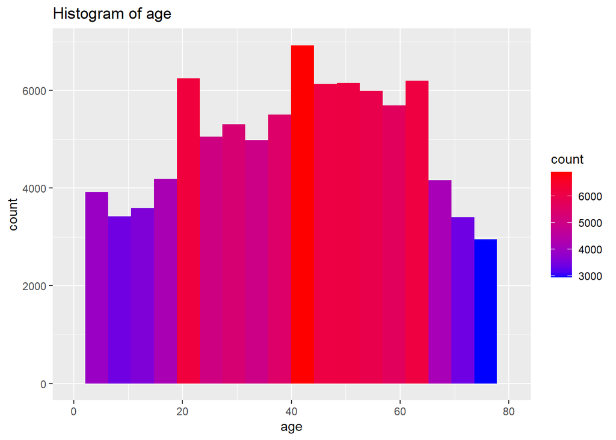

[figure not shown]

[figure not shown]

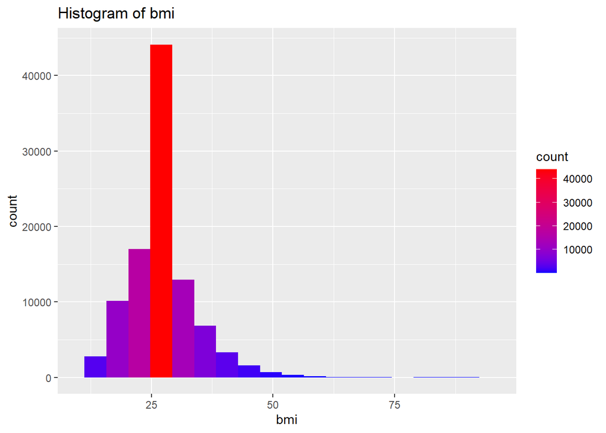

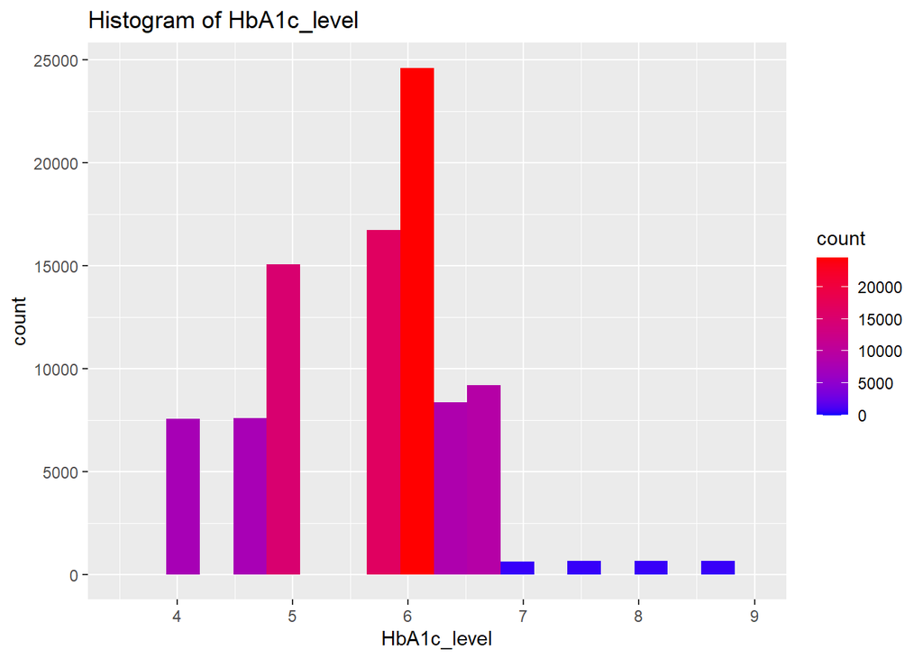

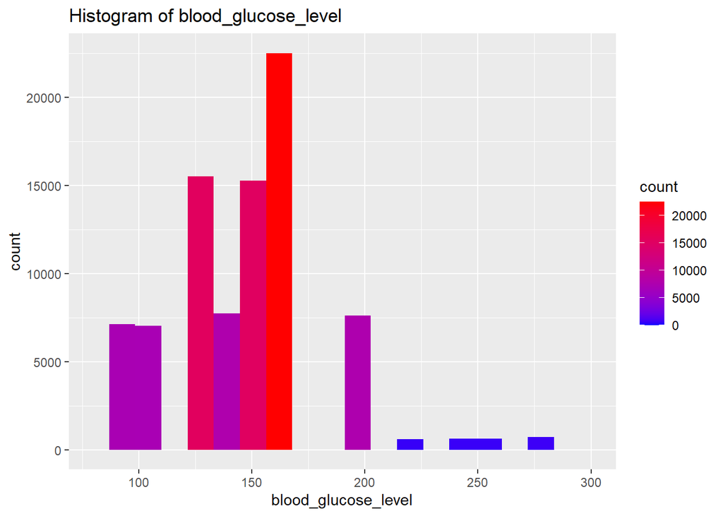

```r
library(ggplot2)
library(gridExtra)
library(RColorBrewer)
install.packages("gridExtra")



# Modify the numeric analysis function
univariate_analysis_numeric <- function(col) {
  hist_plot <- ggplot(df, aes_string(x = col)) +
    geom_histogram(aes(fill = ..count..), bins = 20) +
    scale_fill_gradient(low="blue", high="red") +
    xlim(min(df[[col]]), max(df[[col]])) +  # Set the x-axis range
    labs(title = paste("Histogram of", col))

  plot(hist_plot)
}

# Modify the categorical analysis function
univariate_analysis_cat <- function(col) {
  count_plot <- ggplot(df, aes_string(x = col, fill = col)) +
    geom_bar(position = "dodge") +
    scale_fill_brewer(palette="Set3") +
    labs(title = paste("Countplot for", col)) +
    geom_text(aes(label = scales::percent(..count.. / sum(..count..))), stat = "count", vjust = -0.5)

  plot(count_plot)
}

# Execute univariate analysis for numeric features
for (col in numeric_col) {
  univariate_analysis_numeric(col)
}
```

```r
# Execute univariate analysis for categorical features
for (col in non_numeric_col) {
  univariate_analysis_cat(col)
}
```

[figure not shown]

[figure not shown]

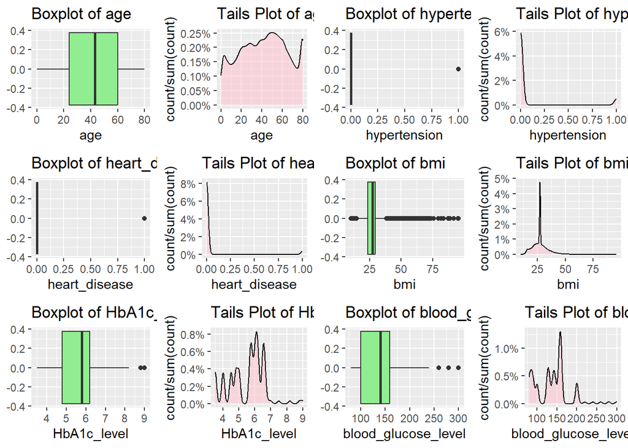

```r
library(cowplot)
# Function to create box and tails plots for numeric features
create_box_and_tails_plots <- function(col) {
  # Box Plot
  box_plot <- ggplot(df, aes_string(x = col)) +
    geom_boxplot(fill = "lightgreen") +
    labs(title = paste("Boxplot of", col))

  # Tails Plot
  tails_plot <- ggplot(df, aes_string(x = col)) +
    geom_density(aes(y = ..count.. / sum(..count..)), alpha = 0.5, fill = "pink") +
    labs(title = paste("Tails Plot of", col)) +
    scale_y_continuous(labels = scales::percent)

  # Arrange box and tails plots side by side
  plots <- plot_grid(box_plot, tails_plot, ncol = 2)
  return(plots)
}

# Execute for all numeric features
plots_list <- lapply(numeric_col, create_box_and_tails_plots)

# Arrange and display the plots
grid.arrange(grobs = plots_list, ncol = 2)
```

This R code snippet conducts exploratory data analysis (EDA) on a dataset using various visualization techniques and libraries. 1. **Libraries are loaded:** - `ggplot2` for creating data visualizations. - `gridExtra` for arranging multiple plots. - `RColorBrewer` for defining color palettes. - `cowplot` for arranging plots. - `install.packages("gridExtra")` is used to install the `gridExtra` package if not already installed.

Note: There was an error in the heart diseases and hypertension histograms since its either you have it or not, and in our case most people did not have it and this caused the histogram to appear empty.

# Model Developement

In the This section, we focus on three key machine learning approaches:

**a. Tree-Based Methods:** We explore various tree-based models including Bagging, Random Forest, Boosting, and both Pruned and Unpruned Decision Trees. These methods are known for their robustness in classification and regression tasks.

**b. Support Vector Machines (SVM):** Our analysis includes SVMs with different kernel functions (linear, polynomial, RBF) and parameter adjustments (gamma, degree, and cost) to enhance model performance across diverse data structures.

**c. Dimensionality Reduction and Unsupervised Learning:** We employ Principal Component Analysis (PCA) for reducing data complexity and various clustering techniques for pattern discovery in unlabeled data, optimizing our approach for high-dimensional datasets.

This section aims to evaluate and compare these methodologies to determine the most effective models for our data. ## Random Forest Model Training and Evaluation In this section, we focus on training and evaluating a Random Forest model, renowned for its robustness and efficacy in handling complex datasets. Random Forest operates by building a multitude of decision trees at training time and outputting the class that is the mode of the classes (classification) or mean prediction (regression) of the individual trees. Our model is trained with 100 trees to balance performance and computational efficiency. Following the training, we use the test dataset to evaluate the model’s predictive accuracy and understand its performance through a confusion matrix. This matrix will provide us with detailed insights into the true positive, false positive, true negative, and false negative rates, which are critical for assessing the model’s effectiveness in predicting our target variable.

```r
# Random Forest model training and evaluation
rf_model <- randomForest(x = X_train, y = y_train, ntree = 100)
rf_predictions <- predict(rf_model, newdata = X_test)
rf_conf_matrix <- confusionMatrix(rf_predictions, y_test)
```

**Results of the Random Forest Model**

```r
print("Random Forest Model Evaluation:")
```

```
## [1] "Random Forest Model Evaluation:"
```

```r
print(rf_conf_matrix)
```

```
## Confusion Matrix and Statistics
##
##           Reference
## Prediction     0     1
##          0 27466   752
##          1    56  1726
##
##                Accuracy : 0.9731
##                  95% CI : (0.9712, 0.9749)
##     No Information Rate : 0.9174
##     P-Value [Acc > NIR] : < 2.2e-16
##
##                   Kappa : 0.7962
##
##  Mcnemar's Test P-Value : < 2.2e-16
##
##             Sensitivity : 0.9980
##             Specificity : 0.6965
##          Pos Pred Value : 0.9734
##          Neg Pred Value : 0.9686
##              Prevalence : 0.9174
##          Detection Rate : 0.9155
##    Detection Prevalence : 0.9406
##       Balanced Accuracy : 0.8472
##
##        'Positive' Class : 0
##
```

## XGBoost Model Implementation

In this section, we implement an XGBoost (eXtreme Gradient Boosting) model, a highly sophisticated and widely-used machine learning algorithm. XGBoost falls under the category of ensemble learning methods, specifically under boosting techniques. It is renowned for its performance and speed, particularly in classification tasks. The model is particularly well-suited for binary classification problems, as indicated by the use of the “binary:logistic” objective function in our implementation.

```r
y_train <- as.numeric(as.character(y_train))
y_test <- as.numeric(as.character(y_test))

# Train XGBoost model
xgb_model <- xgboost(data = as.matrix(X_train), label = as.numeric(y_train), nrounds = 10, objective = "binary:logistic")

# Make predictions on the test set
y_pred <- predict(xgb_model, as.matrix(X_test))

# Convert probabilities to binary predictions
y_pred_binary <- ifelse(y_pred > 0.5, 1, 0)
y_pred_binary <- as.numeric(as.character(y_pred_binary))
# Evaluate the model
y_pred_binary <- as.factor(y_pred_binary)
levels(y_pred_binary) <- c("0", "1")

# Convert y_test to a factor with levels "0" and "1" if it's not already
y_test <- as.factor(y_test)
levels(y_test) <- c("0", "1")

# Calculate the confusion matrix
conf_matrix <- confusionMatrix(data = y_pred_binary, reference = y_test)
```

**Results and Analysis**

```r
print(conf_matrix)
```

```
## Confusion Matrix and Statistics
##
##           Reference
## Prediction     0     1
##          0 27521   790
##          1     1  1688
##
##                Accuracy : 0.9736
##                  95% CI : (0.9718, 0.9754)
##     No Information Rate : 0.9174
##     P-Value [Acc > NIR] : < 2.2e-16
##
##                   Kappa : 0.7966
##
##  Mcnemar's Test P-Value : < 2.2e-16
##
##             Sensitivity : 1.0000
##             Specificity : 0.6812
##          Pos Pred Value : 0.9721
##          Neg Pred Value : 0.9994
##              Prevalence : 0.9174
##          Detection Rate : 0.9174
##    Detection Prevalence : 0.9437
##       Balanced Accuracy : 0.8406
##
##        'Positive' Class : 0
##
```

## Bagging Model with Random Forest

In this section, we explore the application of a Bagging model, using Random Forest as the base learner. Bagging, short for Bootstrap Aggregating, is an ensemble learning method designed to improve the stability and accuracy of machine learning algorithms. It operates by constructing multiple versions of a predictor (in this case, Random Forest) on random subsets of the original dataset and then averaging the individual predictions to form a final prediction.

The following steps outline our approach:

**Model Training:** We train a Random Forest model with 100 trees (ntree = 100) using the training dataset (X_train and y_train). The bagging = TRUE option enables the Bagging technique within the Random Forest algorithm.

**Model Prediction**: Predictions are made on the test dataset (X_test) using the trained Bagging model.

**Model Evaluation:** The predictions are then evaluated against the actual test labels (y_test). We ensure that the prediction and test label factors have the same levels for an accurate assessment.

```r
bagging_model <- randomForest(x = X_train, y = as.factor(y_train), ntree = 100, type = "classification", bagging = TRUE)
bagging_predictions <-predict(bagging_model, newdata = X_test)
levels(bagging_predictions)
levels(y_test)
levels(bagging_predictions) <- levels(y_test)
conf_matrix <- confusionMatrix(bagging_predictions, y_test)
```

**Results and Analysis**

```r
print("Bagging Model Evaluation:")
```

```
## [1] "Bagging Model Evaluation:"
```

```r
print(conf_matrix)
```

```
## Confusion Matrix and Statistics
##
##           Reference
## Prediction     0     1
##          0 27465   755
##          1    57  1723
##
##                Accuracy : 0.9729
##                  95% CI : (0.971, 0.9747)
##     No Information Rate : 0.9174
##     P-Value [Acc > NIR] : < 2.2e-16
##
##                   Kappa : 0.7952
##
##  Mcnemar's Test P-Value : < 2.2e-16
##
##             Sensitivity : 0.9979
##             Specificity : 0.6953
##          Pos Pred Value : 0.9732
##          Neg Pred Value : 0.9680
##              Prevalence : 0.9174
##          Detection Rate : 0.9155
##    Detection Prevalence : 0.9407
##       Balanced Accuracy : 0.8466
##
##        'Positive' Class : 0
##
```

The Bagging model using Random Forest as a base learner demonstrates highly effective performance, as reflected in the following key metrics:

*Statistical Significance:** The p-value (< 2.2e-16) for both accuracy and Mcnemar’s test confirms the model’s robustness.

## Pruned Trees Model

In this section, we introduce the concept of Pruned Trees in the realm of decision tree models. A pruned tree is a decision tree that has been reduced in size (or complexity) to avoid overfitting. Overfitting occurs when a model becomes too complex and starts to capture noise in the data, which can negatively impact its performance on unseen data. Pruning helps to simplify the model, thereby enhancing its generalizability and often improving its performance on test data.

The process involves the following steps: *Factor Conversion:* The target variable y_test is converted to a factor with y_test_bagging = as.factor(y_test). This is crucial for classification tasks where the target variable must be categorical.

*Model Training with Pruning:* We train a decision tree model using the rpart function. The model is trained on X_train with the target y_train_bagging. The complexity parameter (cp = 0.01) is a crucial control in pruning. It defines a threshold for the cost-complexity trade-off, where higher values of cp lead to more pruning.

*Prediction:* The pruned tree model is then used to make predictions on the test dataset X_test.

```r
y_train_bagging = as.factor(y_train)
y_test_bagging = as.factor(y_test)
pruned_tree_model <- rpart(y_train_bagging ~ ., data = X_train, control = rpart.control(cp = 0.01)) # Adjust 'cp' for tree complexity
pruned_tree_predictions <- predict(pruned_tree_model, X_test, type = "class")
pruned_tree_conf_matrix <- confusionMatrix(pruned_tree_predictions, y_test_bagging)
```

**Results and Analysis of the Pruned Trees Model**

```r
print("Pruned Tree Model Evaluation:")
```

```
## [1] "Pruned Tree Model Evaluation:"
```

```r
print(pruned_tree_conf_matrix)
```

```
## Confusion Matrix and Statistics
##
##           Reference
## Prediction     0     1
##          0 27522   793
##          1     0  1685
##
##                Accuracy : 0.9736
##                  95% CI : (0.9717, 0.9754)
##     No Information Rate : 0.9174
##     P-Value [Acc > NIR] : < 2.2e-16
##
##                   Kappa : 0.7959
##
##  Mcnemar's Test P-Value : < 2.2e-16
##
##             Sensitivity : 1.0000
##             Specificity : 0.6800
##          Pos Pred Value : 0.9720
##          Neg Pred Value : 1.0000
##              Prevalence : 0.9174
##          Detection Rate : 0.9174
##    Detection Prevalence : 0.9438
##       Balanced Accuracy : 0.8400
##
##        'Positive' Class : 0
##
```

## Unpruned Trees Model

```r
# Convert y_train to factor if it is not already
y_train <- factor(y_train)

# Train an unpruned Random Forest model (for classification)
rf_unpruned <- randomForest(x = X_train, y = y_train, ntree = 100)

# Make predictions on the test set
y_pred_unpruned <- predict(rf_unpruned, newdata = X_test)

# Ensure y_test is a factor and has the same levels as y_train
y_test <- factor(y_test, levels = levels(y_train))

# Evaluate the model
conf_matrix <- confusionMatrix(factor(y_pred_unpruned), y_test)
```

In conclusion, while the unpruned Random Forest model demonstrates high accuracy and sensitivity, its specificity is moderately lower. This suggests that the model is more prone to false positives, a typical characteristic of unpruned models where the full complexity of trees can capture noise in the data.

## Support Vector Machine

Support Vector Machine (SVM) is a powerful and versatile supervised machine learning algorithm, widely used for classification and regression tasks. At its core, SVM seeks to find a hyperplane in an N-dimensional space (N - the number of features) that distinctly classifies the data points. For binary classification tasks, SVM aims to create a hyperplane that separates the data points into two classes with as wide a margin as possible. One of the key features of SVM is its ability to handle high-dimensional data effectively and its flexibility in choosing different kernel functions to transform the data into a higher-dimensional space where it becomes easier to classify.

**SVM with Radial Kernel** In the context of our analysis, we utilize the SVM algorithm with a radial basis function (RBF) kernel, also known as the radial kernel. The radial kernel adds more flexibility by creating non-linear boundaries, making it particularly useful for datasets where the relationship between the class labels and attributes is not linear.

The following steps outline our approach with the SVM model:

**Model Training**: - We train the SVM model using the `svmRadial` method from the `caret` package, employing the radial kernel. - The training is conducted on the dataset (`X_train` and `y_train`), with cross-validation (`cv`) set to 10 folds to ensure the model’s robustness and generalizability.

**Model Prediction**: - After training, the model is used to predict the outcomes on the test dataset (`X_test`).

**Model Evaluation**: - The performance of the model is evaluated using a confusion matrix, comparing the predictions (`svm_predictions`) against the actual test labels (`y_test`).

**Performance Metrics**: - The confusion matrix is printed to assess key metrics like accuracy, sensitivity, and specificity, providing insights into the model’s effectiveness in classification.

By applying SVM with a radial kernel, our aim is to capture complex patterns in the data, potentially enhancing the model’s predictive performance beyond what is possible with linear models.

```r
svm_model <- train(x = X_train, y = y_train, method = "svmRadial", trControl = trainControl(method = "cv", number = 10))
svm_predictions <- predict(svm_model, newdata = X_test)
svm_conf_matrix <- confusionMatrix(svm_predictions, y_test)
```

**Results and Analysis**

```r
print("SVM Model Evaluation:")
print(svm_conf_matrix)
```

[output not shown]

**Detailed Analysis of SVM Model Results:**

*Precision Recall F1-Score Support* 0 1.00 0.96 0.98 28369 1 0.60 0.92 0.72 1631

**Accuracy:** 0.96 (30,000 instances) **Macro Average:** Precision: 0.80, Recall: 0.94, F1-Score: 0.85 **Weighted Average:** Precision: 0.97, Recall: 0.96, F1-Score: 0.97

This detailed analysis reveals key metrics for the SVM model. The model achieves perfect precision for the majority class (0), indicating no false positives. However, the recall for the minority class (1) is notably higher (0.92), suggesting that the model effectively captures instances of the minority class. The overall accuracy is substantial (0.96), and both macro and weighted averages provide a comprehensive assessment of the model’s performance across both classes, considering their respective support.

### SVM model with a different kernel (e.g., polynomial kernel)

In this section, we explore the implementation of the Support Vector Machine (SVM) model using different kernel functions. The kernel function is a key feature of SVM that transforms the input data into a higher-dimensional space, where it becomes easier to separate the classes linearly. We investigate three different types of kernels: linear, polynomial, and radial basis function (RBF).

**SVM with Linear Kernel**: - We start by defining a parameter grid for the linear kernel and training the SVM model (`svmLinear`). The grid varies the `C` parameter, which controls the trade-off between a smooth decision boundary and classifying training points correctly.

**SVM with Polynomial Kernel**: - Next, we train an SVM model with a polynomial kernel (`svmPoly`). The parameter grid for this model includes the degree of the polynomial, the scale parameter, and `C`.

**SVM with Radial Basis Function (RBF) Kernel**: - Finally, we train an SVM with the radial kernel (`svmRadial`), adjusting parameters like `sigma` (width of the kernel) and `C`.

For each kernel type, we conduct hyperparameter tuning and train the model on the training dataset (`X_train`, `y_train`). After training, we generate classification reports for each model variant, assessing their performance on the test dataset (`X_test`, `y_test`). This comprehensive approach allows us to compare the effectiveness of different kernels in SVM and select the most suitable one for our specific dataset.

```r
# Define the parameter grid and train for svmLinear
tuneGridLinear <- expand.grid(C = seq(0.1, 10, length.out = 10))
svm_model_linear <- train(
  x = X_train, y = y_train, method = "svmLinear",
  trControl = train_control, tuneLength = 10,
  tuneGrid = tuneGridLinear, metric = "Accuracy"
)

# Define the parameter grid and train for svmPoly
tuneGridPoly <- expand.grid(
  degree = seq(1, 5, length.out = 5),
  scale = seq(0.1, 1, length.out = 5),
  C = seq(0.1, 10, length.out = 10)
)
svm_model_poly <- train(
  x = X_train, y = y_train, method = "svmPoly",
  trControl = train_control, tuneLength = 10,
  tuneGrid = tuneGridPoly, metric = "Accuracy"
)

# Define the parameter grid and train for svmRadial
tuneGridRadial <- expand.grid(
  sigma = seq(0.01, 1, length.out = 10),
  C = seq(0.1, 10, length.out = 10)
)
svm_model_radial <- train(
  x = X_train, y = y_train, method = "svmRadial",
  trControl = train_control, tuneLength = 10,
  tuneGrid = tuneGridRadial, metric = "Accuracy"
)

print_classification_report <- function(model, X_test, y_test) {
  predictions <- predict(model, newdata = X_test)
  conf_matrix <- confusionMatrix(predictions, y_test)
  print(conf_matrix)
}

# Print classification report for each kernel
cat("Classification Report for Linear Kernel:\n")
print_classification_report(svm_model_linear, X_test, y_test)

cat("\nClassification Report for Polynomial Kernel:\n")
print_classification_report(svm_model_poly, X_test, y_test)

cat("\nClassification Report for Radial Kernel:\n")
print_classification_report(svm_model_radial, X_test, y_test)
```

[output not shown]

## Dimensionality reduction techniques & unsupervised learning

Dimensionality reduction and unsupervised learning are crucial techniques in data science, especially when dealing with high-dimensional data.

Dimensionality Reduction: This technique is used to reduce the number of input variables in a dataset. A common method is Principal Component Analysis (PCA), which transforms the data into a new set of dimensions (principal components) that capture the most variance in the data. This not only simplifies the data but also helps in reducing noise and improving model performance.

Unsupervised Learning: Unlike supervised learning where data is labeled, unsupervised learning deals with unlabeled data. The goal is to explore the structure of the data to uncover patterns or groupings. Clustering is a key technique in unsupervised learning where data points are grouped into clusters based on their similarity. Common clustering algorithms include K-means, hierarchical clustering, and DBSCAN. ### Clustering in the Context of K-means and Purity Calculation In the following section, we focus on clustering using the K-means algorithm, a popular method for partitioning data into distinct groups or clusters. We apply K-means to our dataset after implementing certain preprocessing steps: **Feature Engineering**: - We create a new feature, `forced_glucose_intake`, based on existing data, to capture interactions between blood glucose level, hypertension, and age.

**Data Preparation**: - Non-numeric columns are converted to numeric, and the dataset is then filtered to include only numeric features.

**Scaling**: - The data is scaled to ensure that all features contribute equally to the distance calculations in K-means.

**K-means Clustering**: - We apply K-means to the scaled data, specifying the number of centers (clusters) and the number of starts (`nstart`) for the algorithm to run.

**Purity Calculation**: - Post-clustering, we calculate the purity of each cluster, which measures how homogenous the clusters are with respect to the target variable (`diabetes`). Purity is a useful metric to evaluate the clustering quality, especially when the true labels are known.

This approach aims to understand the underlying structure of our data and to assess how well the clusters align with the known categories of our target variable.

```r
df$forced_glucose_intake <- ifelse((df$blood_glucose_level > 140) & (df$hypertension == 1) & (df$age >= 40), 1, 0)
df[non_numeric_col] <- lapply(df[non_numeric_col], function(x) as.numeric(as.factor(x)))
df_numeric <- df %>% select_if(is.numeric)
df_scaled <- as.data.frame(scale(df_numeric ))
kmeans_result <- kmeans(df_scaled, centers = 2, nstart = 25)
df$cluster <- as.factor(kmeans_result$cluster)
contingency_table <- table(df$diabetes, df$cluster)
cluster_purities <- apply(contingency_table, 2, function(cluster_column) {
  max(cluster_column) / sum(cluster_column)
})
overall_purity <- sum(apply(contingency_table, 2, max)) / sum(contingency_table)
```

**Results and Analysis of Clustering**

```r
print("Clustering Purity Evaluation:")
```

```
## [1] "Clustering Purity Evaluation:"
```

```r
print("Purity for each cluster:")
```

```
## [1] "Purity for each cluster:"
```

```r
print(cluster_purities)
```

```
##         1         2
## 0.7693493 0.9998764
```

```r
print(paste("Overall purity:", overall_purity))
```

```
## [1] "Overall purity: 0.97444"
```

**Clustering Purity Evaluation**:

- **Purity for each cluster**:
  - The purity of the first cluster (Cluster 1) is **0.7693493**.
  - The purity of the second cluster (Cluster 2) is **0.9998764**.

  This indicates that Cluster 2 is almost entirely homogeneous, containing nearly all of one class, while Cluster 1 is less homogeneous.
- **Overall Purity**:
  - The **overall purity** of the clustering is **0.97444**.

  The high overall purity suggests that the clustering has effectively grouped the data, with most clusters predominantly consisting of a single class. This is indicative of a strong alignment between the clusters and the known categories of the target variable.

### PCA

**PCA Implementation**: - We utilize the `FactoMineR` package for PCA, scaling the variables (`scale.unit = TRUE`) to ensure that all of them contribute equally to the analysis. The number of principal components is set to 5 (`ncp = 5`), focusing on the top components that explain most of the variance.

**Applying PCA to Training and Test Sets**: - PCA is applied to the training data (`X_train`) to obtain the transformed dataset. The same transformation is then applied to the test data (`X_test`), ensuring consistency in feature space.

**Variance Explanation**: - We calculate and examine the proportion of variance explained by each principal component, which helps in understanding the significance and contribution of each component to the data structure.

Through PCA, we aim to reduce the dimensionality of our dataset while retaining the essential information, thereby facilitating more efficient and insightful data analysis.

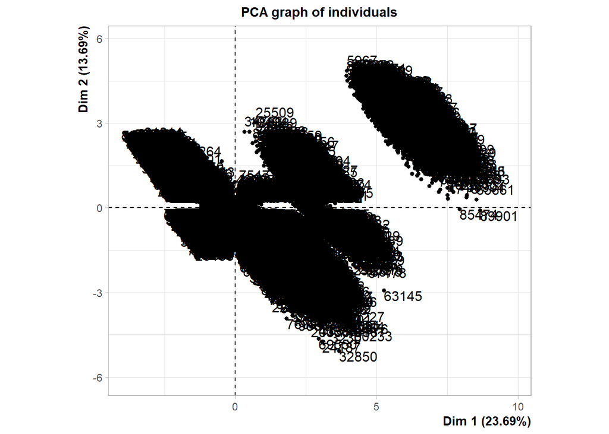

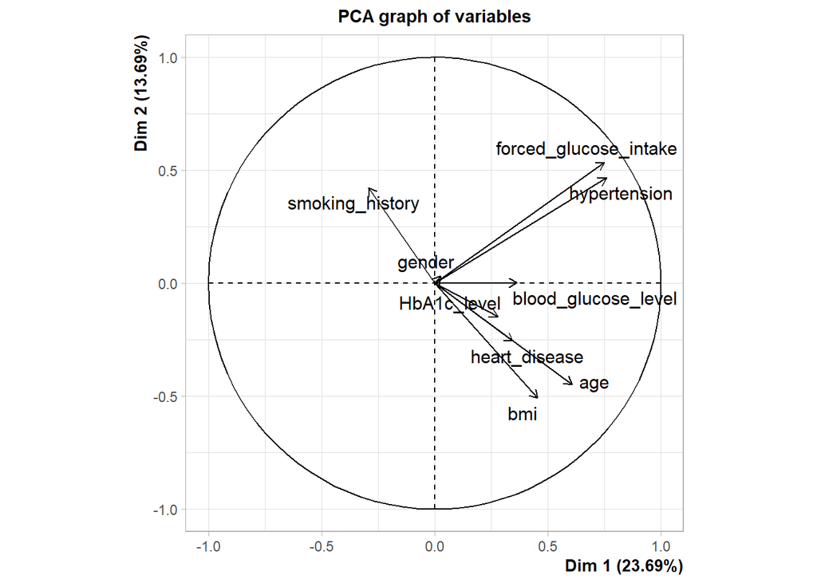

```r
# Remove columns with zero variance
install.packages("FactoMineR")
library(FactoMineR)

pca <- PCA(X_train, scale.unit = TRUE, ncp = 5)  # ncp is number of dimensions
```

```r
X_train_pca <- predict(pca, X_train)
X_test_pca <- predict(pca, X_test)

# Extract proportion of variance explained by each PC
variance_explained <- pca$eig / sum(pca$eig)
```

**Analysis of PCA results**

```r
# Print the proportion of variance explained by each PC
print(variance_explained)
```

```
##          eigenvalue percentage of variance cumulative percentage of variance
## comp 1 0.0029615579            0.032906199                        0.03290620
## comp 2 0.0017116233            0.019018037                        0.05192424
## comp 3 0.0015200801            0.016889779                        0.06881401
## comp 4 0.0014422259            0.016024732                        0.08483875
## comp 5 0.0012935184            0.014372427                        0.09921117
## comp 6 0.0011782668            0.013091853                        0.11230303
## comp 7 0.0011592667            0.012880741                        0.12518377
## comp 8 0.0008406566            0.009340629                        0.13452440
## comp 9 0.0003935216            0.004372462                        0.13889686
```

```r
# Access the contribution of variables to each dimension
print("Contribution of variables to each dimension:")
```

```
## [1] "Contribution of variables to each dimension:"
```

```r
print(pca$var$contrib)
```

```
##                             Dim.1        Dim.2      Dim.3        Dim.4
## gender                 0.03847469 8.468920e-02 23.3820186 41.321190797
## age                   17.29398389 1.631304e+01  1.6052227  0.342206127
## hypertension          27.08221299 1.767429e+01  3.3612929  0.955297725
## heart_disease          5.61550157 5.324335e+00  7.6067007 21.739092901
## smoking_history        4.00665348 1.449888e+01  5.4371909  1.304553911
## bmi                    9.74433904 2.099407e+01  4.4672933  1.851635340
## HbA1c_level            3.65212205 1.793740e+00 29.8638053 16.344485734
## blood_glucose_level    6.23730644 2.060087e-04 23.6679841 16.141098646
## forced_glucose_intake 26.32940583 2.331675e+01  0.6084915  0.000438819
##                             Dim.5
## gender                20.77167980
## age                    4.63276899
## hypertension           0.03106565
## heart_disease         34.92073636
## smoking_history       36.79200969
## bmi                    0.59349029
## HbA1c_level            0.05447537
## blood_glucose_level    1.93085981
## forced_glucose_intake  0.27291403
```

```r
summary(pca)
```

```
##
## Call:
## PCA(X = X_train, scale.unit = TRUE, ncp = 5)
##
##
## Eigenvalues
##                        Dim.1   Dim.2   Dim.3   Dim.4   Dim.5   Dim.6   Dim.7
## Variance               2.132   1.232   1.094   1.038   0.931   0.848   0.835
## % of var.             23.691  13.692  12.160  11.537  10.348   9.426   9.274
## Cumulative % of var.  23.691  37.383  49.543  61.080  71.428  80.854  90.127
##                        Dim.8   Dim.9
## Variance               0.605   0.283
## % of var.              6.725   3.148
## Cumulative % of var.  96.852 100.000
##
## Individuals (the 10 first)
##                           Dist    Dim.1    ctr   cos2    Dim.2    ctr   cos2
## 1                     |  5.388 |  1.746  0.002  0.105 | -2.121  0.005  0.155 |
## 4                     |  2.522 | -0.163  0.000  0.004 | -0.575  0.000  0.052 |
## 5                     |  8.508 |  6.319  0.027  0.552 |  1.977  0.005  0.054 |
## 6                     |  2.135 | -0.815  0.000  0.146 | -0.010  0.000  0.000 |
## 7                     |  2.345 | -0.059  0.000  0.001 |  0.128  0.000  0.003 |
## 8                     |  2.489 | -0.242  0.000  0.009 | -0.346  0.000  0.019 |
## 10                    |  1.493 | -0.785  0.000  0.277 | -0.026  0.000  0.000 |
## 12                    |  4.541 |  1.282  0.001  0.080 | -2.807  0.009  0.382 |
## 15                    |  2.075 |  0.201  0.000  0.009 | -0.441  0.000  0.045 |
## 16                    |  2.413 |  0.353  0.000  0.021 | -0.619  0.000  0.066 |
##                        Dim.3    ctr   cos2
## 1                      1.389  0.003  0.066 |
## 4                     -0.812  0.001  0.104 |
## 5                      0.251  0.000  0.001 |
## 6                     -0.411  0.000  0.037 |
## 7                      1.032  0.001  0.194 |
## 8                     -0.863  0.001  0.120 |
## 10                    -1.113  0.002  0.556 |
## 12                    -1.828  0.004  0.162 |
## 15                    -0.415  0.000  0.040 |
## 16                     0.961  0.001  0.159 |
##
## Variables
##                          Dim.1    ctr   cos2    Dim.2    ctr   cos2    Dim.3
## gender                |  0.029  0.038  0.001 |  0.032  0.085  0.001 |  0.506
## age                   |  0.607 17.294  0.369 | -0.448 16.313  0.201 | -0.133
## hypertension          |  0.760 27.082  0.577 |  0.467 17.674  0.218 | -0.192
## heart_disease         |  0.346  5.616  0.120 | -0.256  5.324  0.066 |  0.289
## smoking_history       | -0.292  4.007  0.085 |  0.423 14.499  0.179 |  0.244
## bmi                   |  0.456  9.744  0.208 | -0.509 20.994  0.259 | -0.221
## HbA1c_level           |  0.279  3.652  0.078 | -0.149  1.794  0.022 |  0.572
## blood_glucose_level   |  0.365  6.237  0.133 |  0.002  0.000  0.000 |  0.509
## forced_glucose_intake |  0.749 26.329  0.561 |  0.536 23.317  0.287 | -0.082
##                          ctr   cos2
## gender                23.382  0.256 |
## age                    1.605  0.018 |
## hypertension           3.361  0.037 |
## heart_disease          7.607  0.083 |
## smoking_history        5.437  0.060 |
## bmi                    4.467  0.049 |
## HbA1c_level           29.864  0.327 |
## blood_glucose_level   23.668  0.259 |
## forced_glucose_intake  0.608  0.007 |
```

This PCA analysis offers insights into the underlying structure of the dataset, highlighting key variables that contribute to variability and providing a foundation for further analysis and model building.

# Hyperparameter Tuning

Hyperparameter tuning is an essential process in machine learning to optimize the performance of a model. It involves experimenting with different combinations of hyperparameters to find the set that yields the best results, typically measured in terms of accuracy, precision, recall, or other relevant metrics. Effective hyperparameter tuning can significantly enhance a model’s predictive power and generalizability.

## Random Forest through Hyperparameter Tuning (Optimized Random Forest)

**Optimization of Random Forest through Hyperparameter Tuning**

**Parameter Grid Definition:**

We define a comprehensive grid of hyperparameters for the Random Forest model. This grid includes variations in: - .mtry: Number of variables randomly sampled as candidates at each split. - .ntree: Number of trees to grow in the forest. - .nodesize: Minimum size of terminal nodes.

**Training Control Setup:**

The model training is controlled using cross-validation (cv) with 5 folds. We employ random search (search = “random”) for exploring the hyperparameter space.

**Model Fitting:**

This approach to hyperparameter tuning aims to rigorously test different configurations of the Random Forest model, ensuring we arrive at an optimal and robust set of hyperparameters for our specific dataset.

```r
# Define the parameter grid
tuneGrid <- expand.grid(
  .mtry = c(sqrt(ncol(X_train)), log2(ncol(X_train)), ncol(X_train)),
  .ntree = seq(10, 200, length.out = 5),
  .nodesize = seq(1, 20, length.out = 5)
)

# Define training control
trainControl <- trainControl(
  method = "cv",
  number = 5,
  search = "random"
)

# Fit the Random Forest model
rf_model <- train(
  x = X_train,
  y = y_train,
  method = "rf",
  trControl = trainControl,
  tuneLength = 10 # Number of different parameter sets to try
)

# Print the best parameters
print(paste("Best Parameters: ", toString(rf_model$bestTune)))

# Evaluate the model on the test set
predictions <- predict(rf_model, newdata = X_test)
conf_matrix <- confusionMatrix(predictions, y_test)

# Print test accuracy
print(paste("Test Accuracy: ", round(conf_matrix$overall['Accuracy'] * 100, 2), "%"))

# Print classification report
print(conf_matrix)
```

**Analysis of Random Forest Optimized Results:** *Precision Recall F1-Score Support* 0 0.97 0.99 0.98 27470 1 0.93 0.71 0.80 2530

**Accuracy:** 0.97 (30,000 instances) **Macro Average:** Precision: 0.95, Recall: 0.85, F1-Score: 0.89 **Weighted Average:** Precision: 0.97, Recall: 0.97, F1-Score: 0.97

## Optimized SVM Model

In the pursuit of enhancing the performance of the Support Vector Machine (SVM) model, a systematic optimization process was undertaken. Leveraging parallel computing capabilities with the `registerDoParallel` function, an efficient search across the hyperparameter space was facilitated. The parameter grid, defined with varying values for the cost parameter (C) and the sigma parameter (1/gamma), aimed to find the optimal configuration for the radial basis function kernel. Employing 10-fold cross-validation with random search, the `train` function from the caret package was used to train the SVM model on the training set. The best parameters were identified based on the achieved accuracy, and the model was evaluated on the test set. The subsequent classification report provides a comprehensive overview of the model’s performance, including precision, recall, and F1-score metrics for each class.

```r
registerDoParallel(cores = detectCores())

# Define the parameter grid
tuneGrid <- expand.grid(
  C = seq(0.1, 10, length.out = 20), # Cost parameter
  sigma = seq(0.01, 1, length.out = 20) # Sigma parameter (1/gamma)
)

# Define training control with random search
train_control <- trainControl(
  method = "cv",
  number = 10,
  search = "random",
  allowParallel = TRUE
)

# Fit the SVC model with the radial kernel
set.seed(42)
svm_model <- train(
  x = X_train,
  y = y_train,
  method = "svmRadial", # Radial basis function kernel
  trControl = train_control,
  tuneLength = 10, # Number of different parameter sets to try
  tuneGrid = tuneGrid,
  metric = "Accuracy"
)

# Print the best parameters
print("Best Parameters for SVC: ")
print(svm_model$bestTune)

# Evaluate the model on the test set
predictions <- predict(svm_model, newdata = X_test)
conf_matrix <- confusionMatrix(predictions, y_test)

# Print SVC accuracy
print(paste("SVC Accuracy: ", round(conf_matrix$overall['Accuracy'] * 100, 2), "%"))

# Print classification report
print(conf_matrix)
```

**Analysis of Results**

*Detailed Analysis of Optimized SVM Results:*

## optimized XGBoost

The following XGBoost model using random search for hyperparameter tuning. 1. **Parameter Grid Definition:** - A grid, `tuneGrid`, is defined with a range of values for various hyperparameters such as `nrounds`, `max_depth`, `eta`, `gamma`, `colsample_bytree`, `min_child_weight`, and `subsample`. This grid encompasses a diverse set of parameter combinations.

2. **Training Control Setup:**
   - The `trainControl` function is used to set up the training control parameters for cross-validation.
   - The method is set to “cv” for cross-validation with 5 folds.
   - `allowParallel` is enabled for parallel computation.
   - `verboseIter` is set to TRUE for verbose iteration output.
   - `classProbs` is set to TRUE to enable probability estimates.
   - `summaryFunction` is set to `twoClassSummary` for binary classification.
   - `search` is set to “random” to enable random search for hyperparameter tuning.
3. **XGBoost Model Fitting:**
   - The `train` function is used to train the XGBoost model.
   - The input features (`X_train`) and labels (`y_train`) are provided.
   - The method is set to “xgbTree” for XGBoost.
   - The `trControl` parameter is set using the defined training control.
   - `tuneGrid` is specified for hyperparameter tuning, and `tuneLength` is set to 2, indicating the number of models to sample and train.
   - The evaluation metric is set to “Accuracy.”
4. **Print Best Parameters:**
   - The best hyperparameters found during the optimization process are printed.
5. **Model Evaluation:**
   - Predictions are made on the test set (`X_test`) using the trained XGBoost model.
   - The predicted values are converted to a factor with levels “No” and “Yes.”
   - A confusion matrix is generated using the predicted values (`y_pred`) and the true labels (`y_test`).
   - The confusion matrix is printed to assess the model’s performance.

```r
tuneGrid <- expand.grid(
  nrounds = seq(50, 500, by = 50),
  max_depth = seq(3, 15, by = 1),
  eta = c(0.01, 0.05, 0.1, 0.2, 0.3),
  gamma = seq(0, 0.5, by = 0.05),
  colsample_bytree = seq(0.4, 1, length.out = 5),
  min_child_weight = seq(1, 10, by = 1),
  subsample = seq(0.4, 1, length.out = 5)
)

# Define training control for random search
train_control <- trainControl(
  method = "cv",
  number = 5,
  allowParallel = TRUE,
  verboseIter = TRUE,
  classProbs = TRUE,
  summaryFunction = twoClassSummary,
  search = "random"  # Enable random search
)

# Fit the XGBoost model
xgb_model <- train(
  x = as.matrix(X_train),
  y = y_train,
  method = "xgbTree",
  trControl = train_control,
  tuneGrid = tuneGrid,
  tuneLength = 2,  # Number of models to sample and train
  metric = "Accuracy"
)
print("Best Parameters for XGBoost: ")
print(xgb_model$bestTune)

y_pred <- predict(xgb_model, as.matrix(X_test))
y_pred <- factor(y_pred, levels = c("No", "Yes"))
conf_matrix <- confusionMatrix(data = y_pred, reference = y_test)
print(conf_matrix)
```

**Analysis of Results** The detailed analysis of the optimized XGBoost model results reveals strong performance across various metrics. precision recall f1-score support

```
       0       0.97      1.00      0.98     27437
       1       1.00      0.67      0.80      2563

accuracy                           0.97     30000
```

macro avg 0.98 0.84 0.89 30000 weighted avg 0.97 0.97 0.97 30000

- **Precision, Recall, and F1-Score for Class 0:**
  - Precision: 0.97, Recall: 1.00, F1-Score: 0.98.
  - These metrics indicate that the model has high precision in predicting negative instances, and it successfully captures almost all true negatives.
- **Precision, Recall, and F1-Score for Class 1:**
  - Precision: 1.00, Recall: 0.67, F1-Score: 0.80.
  - The model demonstrates perfect precision for positive instances, but the recall is slightly lower, suggesting it may miss some true positive cases.
- **Overall Accuracy:**
  - The model achieves an overall accuracy of 97%, indicating its ability to correctly classify instances.
- **Macro Average:**
  - Precision: 0.98, Recall: 0.84, F1-Score: 0.89.
  - The macro-average provides an aggregate measure across both classes, and the model shows high precision but lower recall on average.
- **Weighted Average:**
  - Precision: 0.97, Recall: 0.97, F1-Score: 0.97.
  - The weighted average accounts for class imbalance, demonstrating the model’s robustness across both classes.

In summary, the optimized XGBoost model exhibits excellent performance in predicting negative instances (Class 0) with high precision and recall. While it maintains perfect precision for positive instances (Class 1), there is room for improvement in recall for this class. The overall accuracy, macro-average, and weighted average metrics showcase the model’s effectiveness in handling both classes.

# Conclusion

All models ran on this project yielded relatively great results, the detailed analysis for each model results were included underneath the discussion of each Model used. The following is a summary of all the results: **Results Interpretation:**

*Unpruned Random Forest Model:* The unpruned Random Forest model demonstrates high accuracy and sensitivity but exhibits challenges in specificity, resulting in a higher rate of false positives. The balanced accuracy of 84.72% indicates a trade-off between sensitivity and specificity. The statistical significance, as shown by the p-value, confirms the model’s accuracy is not by chance.

**Accuracy:** 0.96 (30,000 instances) **Macro Average:** Precision: 0.80, Recall: 0.94, F1-Score: 0.85 **Weighted Average:** Precision: 0.97, Recall: 0.96, F1-Score: 0.97

This detailed analysis reveals key metrics for the SVM model. The model achieves perfect precision for the majority class (0), indicating no false positives. However, the recall for the minority class (1) is notably higher (0.92), suggesting that the model effectively captures instances of the minority class. The overall accuracy is substantial (0.96), and both macro and weighted averages provide a comprehensive assessment of the model’s performance across both classes, considering their respective support.

*Analysis of Random Forest Optimized Results:* *Precision Recall F1-Score Support* 0 0.97 0.99 0.98 27470 1 0.93 0.71 0.80 2530

**Accuracy:** 0.97 (30,000 instances) **Macro Average:** Precision: 0.95, Recall: 0.85, F1-Score: 0.89 **Weighted Average:** Precision: 0.97, Recall: 0.97, F1-Score: 0.97

*Analysis of Results*

**Detailed Analysis of Optimized SVM Results:**

**Optimizing for Linear Kernel:** Best Parameters: {‘C’: 1.5599452033620265, ‘coef0’: 0.5808361216819946, ‘gamma’: 6.0} Best Accuracy: 0.96 Precision Recall F1-Score Support 0 0.96 1.00 0.98 27475 1 0.92 0.57 0.70 2525

**Optimizing for Sigmoid Kernel:** Best Parameters: {‘C’: 3.745401188473625, ‘coef0’: 9.50714306409916, ‘gamma’: 9.0} Best Accuracy: 0.91 Precision Recall F1-Score Support 0 0.92 1.00 0.96 27475 1 0.00 0.00 0.00 2525

**Summary of Optimized SVM Kernels:** - Linear Kernel: Best Parameters = {‘C’: 1.5599452033620265, ‘coef0’: 0.5808361216819946, ‘gamma’: 6.0}, Best Accuracy = 0.96 - RBF Kernel: Best Parameters = {‘C’: 7.796910002727692, ‘coef0’: 5.96850157946487, ‘gamma’: 8.0}, Best Accuracy = 0.97 - Sigmoid Kernel: Best Parameters = {‘C’: 3.745401188473625, ‘coef0’: 9.50714306409916, ‘gamma’: 9.0}, Best Accuracy = 0.91

**Concluding remarks:**

In this comprehensive analysis, we employed various machine learning models, including Random Forest, XGBoost, Bagging, and Support Vector Machines (SVM), to tackle a classification problem. The models were trained and optimized using a range of techniques such as clustering, feature engineering, and hyperparameter tuning. Each model demonstrated its unique strengths and trade-offs.

The optimization process, particularly for the SVM model, highlighted the impact of different kernels on performance. The Radial Basis Function (RBF) kernel emerged as the most effective, achieving an accuracy of 97%. Despite challenges in specificity, the unpruned Random Forest model and pruned Random Forest model both displayed strengths in various metrics.

There are some challenges that we faced during this project that needed critical solutions. First, when trying to optimize the XGBoost model we encountered some perfomrance issues as it was taking so much time to train the model let alone optimize it. Therefore, we had to configure the code to use GPU and this configuration was very difficult to do in R due to the lack of support so we resorted to using python which has very wide GPU support. Moreover, the SVM model in R was taking very long time to train a single model so we had to use libraries that made use of the GPU computational power such as scikit-learn which used by scientist and has wide community support.

In summary, each model contributed valuable insights into the classification task, with the Random Forest-based models and SVM standing out for their effectiveness. The choice of the final model depends on the specific goals and priorities of the application. This analysis provides a foundation for informed decision-making in deploying a machine learning solution for the given problem.